# 7.1 The $\chi^2$-Distribution

## Objectives

- Analyze categorical data using $2\times 2$ tables and chi-square analysis.
- Analyze an application in the disciplines business, social sciences, psychology, life sciences, health science, and education, and utilize the correct statistical processes to arrive at a solution.

## The $\chi^2$-Distribution

For the $\chi^2$-distribution (that is, the chi-square distribution), the population mean is $\mu = df$, where $df$ is the degrees of freedom. The population standard deviation is $\sigma = \sqrt{2(df)}$.

The random variable for a $\chi^2$-distribution with $k$ degrees of freedom is the sum of $k$ independent, squared standard normal variables:

$$ \chi^2 = Z_1^2 + Z_2^2 + \cdots + Z_k^2. $$

The curve of the $\chi^2$-distribution is nonsymmetrical. There is a different $\chi^2$ curve for each $df$.

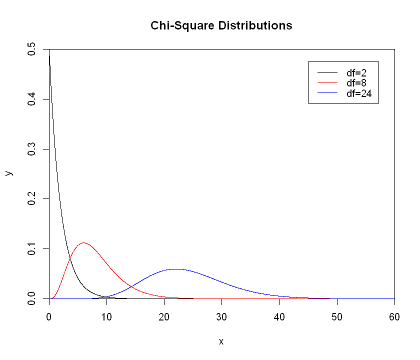

To find the probability to the left or right of a value when using the $\chi^2$-distribution, we will use the R function

```
pchisq(q, df, lower.tail)
```

where we want the probability to the left or right of `q`, the degrees of freedom is `df`, and `lower.tail` is set to either `TRUE` or `FALSE` depending on whether we want to calculate the probability to the left or right of the value.

### Example 1.1

Consider a $\chi^2$-distribution with 4 degrees of freedom.

1. Find $P(\chi^2 < 2)$.
2. Find $P(\chi^2 > 6)$.
3. Find $P(3 < \chi^2 < 5)$.

#### Solution

##### Part 1

We can calculate this simply using R:

```r
pchisq(q = 2, df = 4, lower.tail = TRUE)
```

0.264241117657115

So $P( \chi^2 < 2) = 0.2642$.

##### Part 2

Again, this is simple using R:

```r
pchisq(q = 6, df = 4, lower.tail = FALSE)
```

0.199148273471456

So $P(\chi^2 > 6) = 0.1991$.

##### Part 3

To find $P(3 < \chi^2 < 5)$, we will first calculate *all* the area to the left of $\chi^2 = 5$, then subtract the excess area to the left of $\chi^2 = 3$.

```r
pchisq(q = 5, df = 4, lower.tail = TRUE) - pchisq(q = 3, df = 4, lower.tail = TRUE)
```

0.270527905187429

So $P(3 < \chi^2 < 5) = 0.2705$.

[video not shown]

**License:** This work is licensed under a [Creative Commons Attribution 4.0 International](https://creativecommons.org/licenses/by/4.0/) license.

**Author:** Taylor Baldwin, Mt. San Jacinto College

**Adapted From:** *Introductory Statistics*, by Barbara Illowsky and Susan Dean. Access for free at [https://openstax.org/books/introductory-statistics/pages/1-introduction](https://openstax.org/books/introductory-statistics/pages/1-introduction).